# Sesión 1: LMM

## 0.1 Introducción

En esta sesión aprenderemos la intución que está detrás de los modelos LMM utilizando una base de datos que permita comprender de manera sencilla la importancia de esos modelos. Revisaremos temas descriptivos, la importancia de los grupos y ejecutaremos un modelo de regresión lineal simple.

Antes de ejecutar este documento, instala los paquetes necesarios. Copia y pega el siguiente código en la consola de R:

install.packages (c(“readr”, “dplyr”,“summarytools”,“performance”,“lme4”))

## 0.2 Cargar librerias y datos

En esta primera parte, cargaremos y exploraremos los datos que usaremos para la práctica. No necesitas escribir código: todos los comandos ya están listos para ejecutarse en R.

```r
#Librerias
library(readr)
library(dplyr)
library(summarytools)
library(lme4)
library(performance)

# URL RAW del archivo en GitHub
url <- "https://raw.githubusercontent.com/edwinbhec5-glitch/sesion1_LMM/main/Base_de_estudiantes_por_escuela.csv"

# Descargar a un archivo temporal
temp_file <- tempfile(fileext = ".csv")
download.file(url, destfile = temp_file, mode = "wb")

# Leer con base
datos <- read_csv(temp_file)

#mostrar base
head(datos)
```

```
# A tibble: 6 × 6
  id_estudiante id_escuela genero horas_estudio  nota exper_doc
          <dbl>      <dbl> <chr>          <dbl> <dbl>     <dbl>
1             1          1 Mujer              3  53.8      7.32
2             2          1 Hombre             4  61.6      7.32
3             3          1 Hombre             6  81.5      7.32
4             4          1 Hombre             5  58.2      7.32
5             5          1 Hombre             2  54.1      7.32
6             6          1 Mujer              4  58.2      7.32
```

```r
#mostrar no. grupos
table(datos$id_escuela)
```

```
 1  2  3  4  5  6  7  8  9 10
30 30 30 30 30 30 30 30 30 30
```

# 1 Estadísticos descriptivos

## 1.1 General

```r
descr(datos[, c("horas_estudio", "nota")])
```

```
Descriptive Statistics
datos
N: 300

                    horas_estudio     nota
----------------- --------------- --------
             Mean            4.05    66.59
          Std.Dev            2.16    12.69
              Min            0.00    29.56
               Q1            3.00    57.20
           Median            4.00    65.59
               Q3            5.00    75.15
              Max           11.00   103.92
              MAD            1.48    12.97
              IQR            2.00    17.91
               CV            0.53     0.19
         Skewness            0.67     0.22
      SE.Skewness            0.14     0.14
         Kurtosis            0.69    -0.03
          N.Valid          300.00   300.00
                N          300.00   300.00
        Pct.Valid          100.00   100.00
```

La variable nota, presenta una media de 66.6 con una desviación estándar de 12.7, indicando una dispersión moderada de los puntajes entre los estudiantes. Su distribución muestra una ligera asimetría positiva (skewness = 0.22). En cuanto a la variable explicativa horas de estudio, el promedio es de 4.05 horas, con una desviación estándar de 2.16, y una distribución también ligeramente asimétrica a la derecha (skewness = 0.67). Ambas variables presentan una cobertura completa de observaciones válidas (N = 300)

## 1.2 Por grupos

```r
datos %>%
  group_by(id_escuela) %>%
  summarise(
    promedio_nota = mean(nota),
    sd_nota = sd(nota))
```

```
# A tibble: 10 × 3
   id_escuela promedio_nota sd_nota
        <dbl>         <dbl>   <dbl>
 1          1          62.8   13.2
 2          2          76.6   12.1
 3          3          68.0   11.7
 4          4          59.3   10.7
 5          5          65.2    9.43
 6          6          76.9    9.29
 7          7          55.6    8.54
 8          8          62.9    8.31
 9          9          76.5   11.6
10         10          62.2    9.57
```

Al desagregar los datos por escuela, se observa una variabilidad considerable en las notas promedio entre instituciones. La escuela con el mayor promedio de nota alcanza los 76.9 puntos, mientras que la más baja registra 55.6 puntos, lo que refleja una diferencia de más de 20 puntos entre extremos. Además, la desviación estándar dentro de cada escuela también presenta variaciones, oscilando entre 8.3 y 13.2, lo que sugiere diferencias en la homogeneidad del rendimiento académico al interior de cada grupo escolar.

Estas diferencias sustentan la existencia de una agrupación natural en los datos que debe ser considerada en el análisis.

## 1.3 Gráficos exploratorios

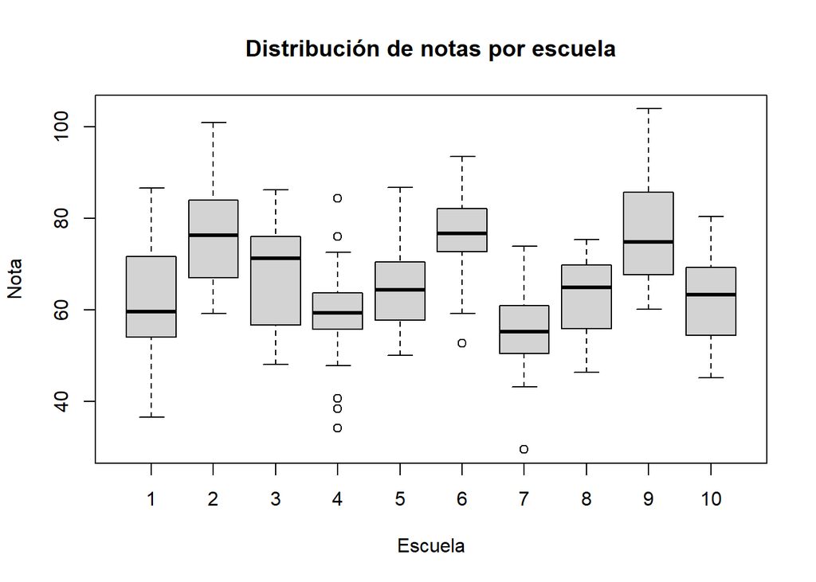

```r
# Boxplot de notas por escuela
boxplot(nota ~ id_escuela, data = datos,
        main = "Distribución de notas por escuela",
        xlab = "Escuela", ylab = "Nota")
```

El boxplot permite ver de manera más clara esas diferencias en la nota por escuela.

## 1.4 Relación entre horas de estudio y nota

Para observar la relación entre la nota y un factor que puede influir en la misma, realizamos un gráfico de dispersión entre la nota y horas de estudio, e incorporamos una linea de tendencia

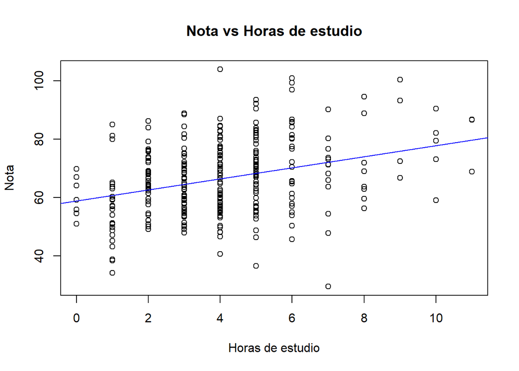

```r
plot(nota ~ horas_estudio, data = datos,
     main = "Nota vs Horas de estudio",
     xlab = "Horas de estudio", ylab = "Nota")
abline(lm(nota ~ horas_estudio, data = datos), col = "blue")
```

# 2 Regresión lineal básica

Para determinar si las horas de estudio influyen sobre la nota, realizamos un Modelo de Regresión Lineal clásico

```r
modelo1 <- lm(nota ~ horas_estudio, data = datos)
summary(modelo1)
```

```
Call:
lm(formula = nota ~ horas_estudio, data = datos)

Residuals:
    Min      1Q  Median      3Q     Max
-42.624  -8.899  -0.218   7.880  37.420

Coefficients:
              Estimate Std. Error t value Pr(>|t|)
(Intercept)    58.9214     1.4807  39.792  < 2e-16 ***
horas_estudio   1.8946     0.3228   5.868 1.17e-08 ***
---
Signif. codes:  0 '***' 0.001 '**' 0.01 '*' 0.05 '.' 0.1 ' ' 1

Residual standard error: 12.04 on 298 degrees of freedom
Multiple R-squared:  0.1036,    Adjusted R-squared:  0.1006
F-statistic: 34.44 on 1 and 298 DF,  p-value: 1.17e-08
```

## 2.1 lm con efectos fijos por escuela

```r
modelo2 <- lm(nota ~ horas_estudio + factor(id_escuela), data = datos)
summary(modelo2)
```

```
Call:
lm(formula = nota ~ horas_estudio + factor(id_escuela), data = datos)

Residuals:
     Min       1Q   Median       3Q      Max
-30.4025  -6.9958  -0.4471   6.8228  28.6310

Coefficients:
                     Estimate Std. Error t value Pr(>|t|)
(Intercept)           56.6357     2.1863  25.904  < 2e-16 ***
horas_estudio          1.4620     0.2772   5.275 2.61e-07 ***
factor(id_escuela)2   13.6539     2.6090   5.233 3.21e-07 ***
factor(id_escuela)3    5.8313     2.6121   2.232  0.02636 *
factor(id_escuela)4   -1.8897     2.6278  -0.719  0.47265
factor(id_escuela)5    3.0930     2.6121   1.184  0.23736
factor(id_escuela)6   13.4919     2.6109   5.167 4.43e-07 ***
factor(id_escuela)7   -6.9075     2.6097  -2.647  0.00857 **
factor(id_escuela)8    0.4398     2.6097   0.169  0.86629
factor(id_escuela)9   12.8052     2.6137   4.899 1.60e-06 ***
factor(id_escuela)10  -0.1424     2.6103  -0.055  0.95654
---
Signif. codes:  0 '***' 0.001 '**' 0.01 '*' 0.05 '.' 0.1 ' ' 1

Residual standard error: 10.1 on 289 degrees of freedom
Multiple R-squared:  0.3875,    Adjusted R-squared:  0.3663
F-statistic: 18.28 on 10 and 289 DF,  p-value: < 2.2e-16
```

Al agregar indicadores de escuela (variables ficticias o dummies), se permite que cada escuela tenga su nota promedio distinta (su intercepto). De esta forma controlamos explícitamente las diferencias sistemáticas entre escuelas.

Si comparamos frente al modelo anterior, se observa que la nota general promedio disminuyó y que existen diferencias significativas entre algunas escuelas y la escuela 1 (escuela de referencia).

Además, el coeficiente de horas_estudio sigue siendo significativo, pero tiene un efecto menor. Este coeficiente refleja el efecto promedio ajustado dentro de cada escuela (es decir, controlando por las diferencias de nivel de escuela).

Esta especificación mejora el ajuste frente al modelo simple, pues quita parte de la variabilidad entre escuelas.

PROBLEMA: implica estimar muchos parámetros (uno por escuela), lo cual puede reducir la eficiencia si hay muchas escuelas o pocos datos por escuela. Además, no permite generalizar más allá de las escuelas incluidas.

## 2.2 Modelo jerárquico

### 2.2.1 Modelo nulo

```r
modelo3 <- lmer(nota ~ 1 + (1 | id_escuela), data = datos)
summary(modelo3)
```

```
Linear mixed model fit by REML ['lmerMod']
Formula: nota ~ 1 + (1 | id_escuela)
   Data: datos

REML criterion at convergence: 2288.7

Scaled residuals:
     Min       1Q   Median       3Q      Max
-2.52954 -0.72935 -0.04771  0.63457  2.65942

Random effects:
 Groups     Name        Variance Std.Dev.
 id_escuela (Intercept)  54.89    7.409
 Residual               111.54   10.561
Number of obs: 300, groups:  id_escuela, 10

Fixed effects:
            Estimate Std. Error t value
(Intercept)   66.594      2.421   27.51
```

```r
performance::icc(modelo3)
```

```
# Intraclass Correlation Coefficient

    Adjusted ICC: 0.330
  Unadjusted ICC: 0.330
```

Vemos que el promedio de la nota media global tuvo un cambio importante frente a los anteriores modelos (66.59).

La Varianza entre escuelas (54.89) indica que los estudiantes no son completamente independientes entre sí: quienes pertenecen a la misma escuela tienden a parecerse más entre ellos.

Por otro lado, la varianza residual (diferencias dentro de escuelas: 111.54) muestra cuánto varían los notas de los estudiantes dentro de cada escuela.

El Coeficiente de correlación intraclase (ICC) de 0.33, indica que la variabilidad total en las notas se debe a diferencias entre escuelas. Es un valor relativamente alto, lo que justifica usar modelos jerárquicos y es una evidencia de que sería un error aplicar un modelo tradicional que no reconozca esta estructura de agrupamiento.

### 2.2.2 Con covariable

```r
modelo4 <- lmer(nota ~ horas_estudio + (1 | id_escuela), data = datos)
summary(modelo4)
```

```
Linear mixed model fit by REML ['lmerMod']
Formula: nota ~ horas_estudio + (1 | id_escuela)
   Data: datos

REML criterion at convergence: 2261.6

Scaled residuals:
     Min       1Q   Median       3Q      Max
-3.08923 -0.70279 -0.04353  0.65119  2.89304

Random effects:
 Groups     Name        Variance Std.Dev.
 id_escuela (Intercept)  48.09    6.935
 Residual               102.10   10.105
Number of obs: 300, groups:  id_escuela, 10

Fixed effects:
              Estimate Std. Error t value
(Intercept)    60.5525     2.5310   23.93
horas_estudio   1.4919     0.2768    5.39

Correlation of Fixed Effects:
            (Intr)
horas_estud -0.443
```

```r
performance::icc(modelo4)
```

```
# Intraclass Correlation Coefficient

    Adjusted ICC: 0.320
  Unadjusted ICC: 0.300
```

En el modelo con una variable explicativa como las horas de estudio, se observa que la nota promedio global es de 60.55. Y el coeficiente de horas de estudio (1.49) es significativo.

Por otro lado, la varianza entre escuelas (48.09) bajó frente al modelo anterior, lo que sugiere que parte de las diferencias entre escuelas se deben a las horas de estudio, pero sigue siendo altamente importante la consideración de los grupos ya que el ICC es de 0.32 (una ligera disminución frente al modelo nulo)

# 3 Con covariable nivel escuela

```r
modelo5 <- lmer(nota ~ horas_estudio+exper_doc + (1 | id_escuela), data = datos)
summary(modelo5)
```

```
Linear mixed model fit by REML ['lmerMod']
Formula: nota ~ horas_estudio + exper_doc + (1 | id_escuela)
   Data: datos

REML criterion at convergence: 2243

Scaled residuals:
    Min      1Q  Median      3Q     Max
-3.0833 -0.6782 -0.0379  0.6858  2.9742

Random effects:
 Groups     Name        Variance Std.Dev.
 id_escuela (Intercept)   4.739   2.177
 Residual               102.095  10.104
Number of obs: 300, groups:  id_escuela, 10

Fixed effects:
              Estimate Std. Error t value
(Intercept)    27.0912     4.9222   5.504
horas_estudio   1.4713     0.2757   5.337
exper_doc       4.4893     0.6440   6.971

Correlation of Fixed Effects:
            (Intr) hrs_st
horas_estud -0.137
exper_doc   -0.957 -0.092
```

```r
performance::icc(modelo5)
```

```
# Intraclass Correlation Coefficient

    Adjusted ICC: 0.044
  Unadjusted ICC: 0.029
```

Al incluir la experiencia docente se observa que ese factor explica la variabilidad entre escuelas, por lo que el efecto de grupo de escuelas se reduce considerablemente, pues la variabilidad entre las escuelas estaba explicada por este factor.

## 3.1 Comparación de modelos

```r
AIC(modelo1, modelo2, modelo4)
```

```
        df      AIC
modelo1  3 2348.175
modelo2 12 2251.938
modelo4  4 2269.575
```

Al comparar los 3 modelos, aunque el modelo con efectos fijos (modelo 2) tiene el menor AIC, el modelo 4 tiene ventajas de parsimonia y captura elementos que no se podría analizar únicamente con un modelo más simple.

## 3.2 Conclusión

Las escuelas influyen en el rendimiento de los estudiantes (Modelo 3). Las horas de estudio también tienen un efecto importante (Modelo 4). Combinar ambos elementos permite una mejor comprensión de los factores que afectan las notas.

El modelo jerárquico no solo estima el efecto general de estudiar más, sino que también permite entender la variación entre escuelas y aplicar modelos más realistas.

# 4 Reflexión

Podríamos hacer un modelo agrupando por sexo?. Los datos de las notas promedio por sexo son los siguientes:

```r
tapply(datos$nota, datos$genero, mean)
```

```
  Hombre    Mujer
67.33985 65.98467
```